# Práctica Data Driven Security

Grupo G: Yaneth Gonzalez, Miriam Jiménez, Anabel Vílchez y Alejandro Moreno

2018-06-03

# 1. Introducción

El propósito de la práctica es evidenciar las posibles vulnerabilidades industriales que pueden darse en diferentes países. La pregunta que intentamos responder es si **existe algun país más propenso a tener vulnerabilidades industriales**. Para este análisis se utilizaran diferentes fuentes de datos que serán tratados con R.

La fase más importante del análisis es la búsqueda en [Shodan](http://www.shodan.io) de todos los dispositivos industriales públicos en Internet los cuales los cruzaremos con las vulnerabilidades que tengan este tipo de modelos de dispositivos industriales públicos en la [Common Vulnerabilities and Exposures](https://cve.mitre.org). Para la extración de datos en Shodan utilizaremos el package publico en Github de [hrbrmstr](https://github.com/hrbrmstr/shodan)

Shodan es un motor de búsquedas que ofrece información sobre equipos conectados a Internet ya sean routers, servidores, cámaras de videovigilancia, maquinaria industrial o cualquier otro tipo de dispositivo que se encuentre conectado. Permite buscar información masiva de los dispositivos y hacer un filtrado según los intereses que tengamos. Para la realización de esta práctica, vamos a hacer una búsqueda por fabricante y producto de dispositivos industriales

Los repositorios utilizados para los cálculos y descarga de las fuentes de datos se pueden encontrar en el siguiente reposiorio de Github de esta práctica. En este repositorio se encuentra: el script en R para descargar los datos de Shodan, el script para los cálculos intermedios de análisis y los packages dedicados para la práctica.

- https://github.com/amperis/upc-master-datadriven

En el siguiente repositorio se encuentra el informe en R de la documentación de la práctica:

- https://github.com/amperis/upc-master-datadriven-informe

# 2. Descripción de los modelos de datos

Las fuentes de datos que utilizaremos en la práctica serán las siguientes:

1. Fuente de datos con dispositivos industriales según fabricantes.
2. Fuente de datos Shodan de dispositivos industriales accesibles desde Internet.
3. Fuente de datos de CVE.

A continuación se describen las características de cada una de las fuentes de datos.

## 2.1 Fuente de datos con dispositivos industriales según fabricantes

Esta fuente de datos es un archivo CSV generado manualmente a través de los diferentes dispositivos industriales más comunes actualmente. Nos hemos basado en diferente documentación técnica disponible en Internet así como en la documentación impartida en el máster. Un ejemplo de esta información se puede encontrar en la siguiente URL:

- https://cybersecuritylaboratory.wordpress.com/2016/10/05/utilizando-shodan-para-encontrar-sistemas-de-control-industrial

Esta lista debe actualizarse a medida que se conozcan más fabricantes. El encabezado de dicha tabla es el siguiente:

| Campo | Descripción |
| --- | --- |
| fabricante | Campo de tipo string que contiene el nombre del fabricante del dispositivo industrial. |
| producto | Campo de tipo string que contiene el modelo del producto industrial. |
| cadena_busqueda | String de búsqueda en Shodan. |

A continuación se muestran los 15 primeros registros de este CSV:

Tabla 1 - Lista de dispositivos industriales

| fabricante | producto | cadena_busqueda |
| --- | --- | --- |
| Philips | Philips Hue Lighing | http.title:“hue personal wireless lighting” |
| Schneider Electric | PowerLogic ECC | Schneider Electric ECC21 |
| Schneider Electric | PowerLogic EGX | Schneider Electric EGX100MG |
| Schneider Electric | PowerLogic ION | Power Measurement Ltd ION8650 |
| Schneider Electric | PowerLogic ION | Meter ION |
| Schneider Electric | PowerLogic PM | Schneider Electric PM820SD |
| Schneider Electric | PowerLogic PM | PowerLogic PM800 |
| Schneider Electric | PowerLogic PM | PowerLogic PM800 |
| Schneider Electric | PowerLogic PM1 | Schneider Electric PM870SD |
| General Electric | Proficy | ProficyPortal |
| Reliance | Reliance 4 | Reliance 4 Control Server |
| Elster EnergyICT | RTU | EnergyICT RTU |
| ABB | RTU500 | ABB RTU560 |
| Siemens | Scalance S | Scalance S |
| Siemens | Simatic HMI | SIMATIC HMI |

Actualmente se disponen de un total de 85 dispositivos industriales.

La [lista completa de dispositivos industriales](https://github.com/amperis/upc-master-datadriven/blob/master/R/SHODAN/FUENTESDATOS/ORIG/dispositivos_industriales.csv) puede econtrarse en el repositorio de GitHub de la práctica.

## 2.2 Fuente de datos Shodan de dispositivos industriales accesibles desde Internet

Esta fuente de datos es un archivo de datos CVE obtenido a través de un proceso interativo programado en R desde el cual por cada dispositivo industrial obtenido del punto anterior es buscado en Shodan. Esta búsqueda nos devuelve diferente información del dispositivo industrial encontrado y público en Internet. La extración de datos de Shodan pueden encontrarse en el [script de R de la practica](https://github.com/amperis/upc-master-datadriven/tree/master/R/SHODAN).

Las cabeceras obtenidas de la tabla son las siguientes:

| Campo | Descripción |
| --- | --- |
| v_fabricante | String con el nombre del fabricante del dispositovo industrial. |
| v_producto | String con el modelo del producto del dispositivo industrial. |
| v_cadena_busqueda | String con la cadena de búsqueda Shodan que se ha utilizado para encontrar este dispositivo. |
| aux.matches.ip_str | String con la IP pública del dispositivo en formato ICANN de 32 bits. |
| aux.matches.isp | String con el nombre comercial del ISP (Internet Service Provider) de dicha dirección IP. |
| aux.matches.location.city | String de la ciudad donde está ubicada fisicamente dicha IP. |
| aux.matches.location.longitude | String con la coordenada de longitud geográfica. |
| aux.matches.location.latitude | String con la coordenada de latitud geográfica. |
| aux.matches.location.country_name | String con el país. |
| aux.matches.location.country_code3 | String con el país en formato ISO-3166.1. |
| aux.matches.os.au | String con el identificador del Sistema Autónomo al que pertenece la IP. |

A continuación se muestran los 10 primeros registros de este CSV de consultas Shodan:

Tabla 2 - Listado de dispositivos industriales encontrados en Shodan

| v_fabricante | v_producto | v_cadena_busqueda | aux.matches.ip_str | aux.matches.isp | aux.matches.location.city | aux.matches.location.longitude | aux.matches.location.latitude | aux.matches.location.country_name | aux.matches.location.country_code3 | aux.matches.os | aux.matches.org | aux.matches.asn |
| --- | --- | --- | --- | --- | --- | --- | --- | --- | --- | --- | --- | --- |
| Philips | Philips Hue Lighing | http.title:hue personal wireless lighting | 82.197.175.26 | Init7 (Switzerland) Ltd. | Zurich | 8.5500 | 47.3667 | Switzerland | CHE | NA | Init7 (Switzerland) Ltd. | AS13030 |
| Philips | Philips Hue Lighing | http.title:hue personal wireless lighting | 188.2.21.180 | Serbia BroadBand-Srpske Kablovske mreze d.o.o. | Novi Sad | 19.8369 | 45.2517 | Serbia | SRB | NA | Serbia BroadBand-Srpske Kablovske mreze d.o.o. | AS31042 |
| Philips | Philips Hue Lighing | http.title:hue personal wireless lighting | 213.65.61.145 | Telia Company | Falun | 15.6260 | 60.6036 | Sweden | SWE | NA | Telia Network Services | AS3301 |
| Philips | Philips Hue Lighing | http.title:hue personal wireless lighting | 145.14.221.218 | Glattwerk AG | Wallisellen | 8.5967 | 47.4150 | Switzerland | CHE | NA | Glattwerk AG | AS61174 |
| Philips | Philips Hue Lighing | http.title:hue personal wireless lighting | 99.154.9.16 | AT&T U-verse | NA | -97.8220 | 37.7510 | United States | USA | NA | AT&T U-verse | AS7018 |
| Philips | Philips Hue Lighing | http.title:hue personal wireless lighting | 66.74.181.239 | Time Warner Cable | Thousand Oaks | -118.8800 | 34.2133 | United States | USA | NA | Time Warner Cable | AS20001 |
| Philips | Philips Hue Lighing | http.title:hue personal wireless lighting | 160.3.37.217 | Cable One | Pampa | -100.8775 | 35.5418 | United States | USA | NA | Cable One | AS11492 |
| Philips | Philips Hue Lighing | http.title:hue personal wireless lighting | 87.100.253.26 | DNA Oyj | Helsinki | 24.9007 | 60.1942 | Finland | FIN | NA | DNA Oyj | AS16086 |
| Philips | Philips Hue Lighing | http.title:hue personal wireless lighting | 72.182.192.32 | Time Warner Cable | Irving | -96.9613 | 32.8500 | United States | USA | NA | Time Warner Cable | AS11427 |
| Philips | Philips Hue Lighing | http.title:hue personal wireless lighting | 82.169.170.245 | KPN | Breda | 4.7755 | 51.5881 | Netherlands | NLD | NA | KPN | AS1136 |

Actualmente se disponen de un total de 4847 dispositivos industriales.

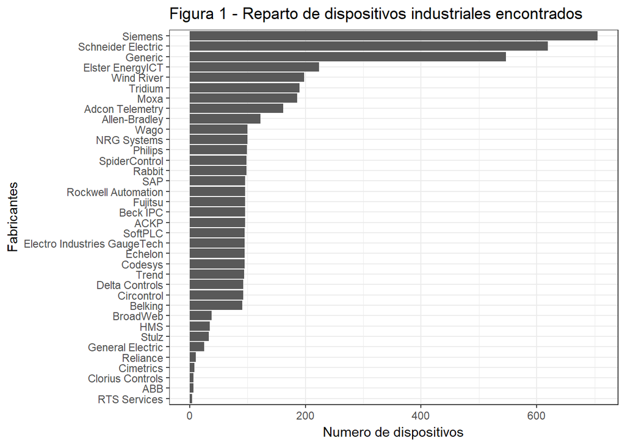

## 2.3 Fuente de datos de CVE

Para la extración de datos de la [Common Vulnerabilities and Exposures](https://cve.mitre.org) hemos utilizado el package público en Github de la [r-net.tools](https://github.com/r-net-tools/security.datasets/raw/master/net.security/sysdata.rda). Esta fuente de datos contiene información de vulnerabilidades así como parches o soluciones aportadas por fabricantes y desarrolladores.

A continuación se describen los campos de esta tabla:

| Campo | Descripción |
| --- | --- |
| cve.id | Identificador del CVE |
| affects | Versiones afectadas |
| problem.type | Tipo de problema |
| references | Información extra sobre el CVE |
| description | Breve descripción de la vulnerabilidad o exposición de seguridad |
| vulnerable.configuration | Configuración de la vulnerabilidad |
| cvss3.vector | Vector de ataque utilizado |
| cvss3.score.exploit | Puntuación del exploit |
| cvss3.score.impact | Puntuación del impacto |
| cvss2.vector | Vector de ataque utilizado |
| published.date | Fecha de publicación del CVE |
| last.modified | Fecha de modificación del CVE |

A continuación se muestran los 3 primeros registros de CVE:

Tabla 3 - Listado de vulnerabilidads CVE

| cve.id | affects | problem.type | references | description | vulnerable.configuration | cvss3.vector | cvss3.av | cvss3.ac | cvss3.pr | cvss3.ui | cvss3.s | cvss3.c | cvss3.i | cvss3.a | cvss3.score | cvss3.severity | cvss3.score.exploit | cvss3.score.impact | cvss2.vector | cvss2.av | cvss2.ac | cvss2.au | cvss2.c | cvss2.i | cvss2.a | cvss2.score | cvss2.score.exploit | cvss2.score.impact | cvss2.getallprivilege | … |
| --- | --- | --- | --- | --- | --- | --- | --- | --- | --- | --- | --- | --- | --- | --- | --- | --- | --- | --- | --- | --- | --- | --- | --- | --- | --- | --- | --- | --- | --- | --- |
| CVE-1999-0001 | [{“vendor_name”:“bsdi”,“product”:{“product_data”:[{“product_name”:“bsd_os”,“version”:{“version_data”:[{“version_value”:“3.1”}]}}]}},{“vendor_name”:“freebsd”,“product”:{“product_data”:[{“product_name”:… | [“CWE-20”] | [{“url”:“http://www.openbsd.org/errata23.html#tcpfix”,“name”:“http://www.openbsd.org/errata23.html#tcpfix”,“refsource”:“CONFIRM”},{“url”:“http://www.osvdb.org/5707”,“name”:“5707”,“refsource”:“OSVDB”}] | [{“lang”:“en”,“value”:“ip_input.c in BSD-derived TCP/IP implementations allows remote attackers to cause a denial of service (crash or hang) via crafted packets.”}] | [{“operator”:“OR”,“cpe”:[{“vulnerable”:true,“cpe22Uri”:“cpe:/o:bsdi:bsd_os:3.1”,“cpe23Uri”:“cpe:2.3:o:bsdi:bsd_os:3.1:*:*:*:*:*:*:*“},{”vulnerable“:true,”cpe22Uri“:”cpe:/o:freebsd:freebsd:1.0“,”cpe23U… | NA | NA | NA | NA | NA | NA | NA | NA | NA | NA | NA | NA | NA | (AV:N/AC:L/Au:N/C:N/I:N/A:P) | NETWORK | LOW | NONE | NONE | NONE | PARTIAL | 5 | 10 | 2.9 | FALSE | … |
| CVE-1999-0002 | [{“vendor_name”:“bsdi”,“product”:{“product_data”:[{“product_name”:“bsd_os”,“version”:{“version_data”:[{“version_value”:“1.1”}]}}]}},{“vendor_name”:“caldera”,“product”:{“product_data”:[{“product_name”:… | [“CWE-119”] | [{“url”:“ftp://patches.sgi.com/support/free/security/advisories/19981006-01-I”,“name”:“19981006-01-I”,“refsource”:“SGI”},{“url”:“http://www.ciac.org/ciac/bulletins/j-006.shtml”,“name”:“J-006”,“refsour… | [{“lang”:“en”,“value”:“Buffer overflow in NFS mountd gives root access to remote attackers, mostly in Linux systems.”}] | [{“operator”:“OR”,“cpe”:[{“vulnerable”:true,“cpe22Uri”:“cpe:/o:bsdi:bsd_os:1.1”,“cpe23Uri”:“cpe:2.3:o:bsdi:bsd_os:1.1:*:*:*:*:*:*:*“},{”vulnerable“:true,”cpe22Uri“:”cpe:/o:caldera:openlinux:1.2“,”cpe2… | NA | NA | NA | NA | NA | NA | NA | NA | NA | NA | NA | NA | NA | (AV:N/AC:L/Au:N/C:C/I:C/A:C) | NETWORK | LOW | NONE | COMPLETE | COMPLETE | COMPLETE | 10 | 10 | 10.0 | TRUE | … |
| CVE-1999-0003 | [{“vendor_name”:“tritreal”,“product”:{“product_data”:[{“product_name”:“ted_cde”,“version”:{“version_data”:[{“version_value”:“4.3”}]}}]}},{“vendor_name”:“hp”,“product”:{“product_data”:[{“product_name”:… | [“NVD-CWE-Other”] | [{“url”:“ftp://patches.sgi.com/support/free/security/advisories/19981101-01-A”,“name”:“19981101-01-A”,“refsource”:“SGI”},{“url”:“ftp://patches.sgi.com/support/free/security/advisories/19981101-01-PX”,… | [{“lang”:“en”,“value”:“Execute commands as root via buffer overflow in Tooltalk database server (rpc.ttdbserverd).”}] | [{“operator”:“OR”,“cpe”:[{“vulnerable”:true,“cpe22Uri”:“cpe:/a:tritreal:ted_cde:4.3”,“cpe23Uri”:“cpe:2.3:a:tritreal:ted_cde:4.3:*:*:*:*:*:*:*“},{”vulnerable“:true,”cpe22Uri“:”cpe:/o:sgi:irix:5.2“,”cpe… | NA | NA | NA | NA | NA | NA | NA | NA | NA | NA | NA | NA | NA | (AV:N/AC:L/Au:N/C:C/I:C/A:C) | NETWORK | LOW | NONE | COMPLETE | COMPLETE | COMPLETE | 10 | 10 | 10.0 | TRUE | … |

Actualmente se encuentran un total de 106717 vulnerabilidades.

# 3. Objetivos del análisis de datos

Los objetivos de esta práctica son:

- Conocer y mantenernos informados sobre los países que poseen riesgos asociados a sus dispositivos industriales, por vulnerabilidades detectadas y reportadas.
- Diferenciar visualmente entre los países que poseen más dispositivos instalados versus los países que poseen más dispositivos con vulnerabilidad.
- Detectar cuál es el fabricante con mayor cantidad de vulnerabilidades reportadas en CVE.

La metodología utilizada para los cálculos que se presentarán a continuación es la siguiente:

1. Dado el listado CSV de dispositivos industriales visto en el punto 2.1 de esta práctica, se realiza un proceso interativo de búsqueda en Shodan.
2. El resultado de la búsqueda en Shodan es un nuevo listado CSV de dispositivos industriales publicados en Internet tal como puede verse en el punto 2.2 de la práctica.
3. Con el listado de CSV de Shodan se buscan las vulnerabilidades CVE que contengan cada uno de estos dispositivos en cada uno de sus países. Esta información se sumariza para obtener cuáles son los países que más vulnerabilidades tienen.

# 4. Análisis de datos

A continuación se analizan los países que más dispositivos industriales públicos en Internet se han encontrado a través de Shodan a nivel mundial.

Utilizamos un mapa de los puntos GPS de dichos dispositivos industriales. Aparentemente los países que más dispositivos industriales utilizan son EEUU y Europa:

Figura 2 - Posición GPS de los dispositivos industriales

[interactive chart not shown]

Se analiza a través de un mapa de calor dicha densidad de puntos para estar seguros. Revisando los datos CSV aparece una casuística que explica la diferencia de los gráficos, la cual es que muchos dispositivos tienen asociada la misma latitud y longitud, por lo que los puntos se sobreponen uno encima de otro tantas veces como se encuentren. Esto es así porque dichos dispositivos industriales pertenecen al mismo ISP (Internet Service Provider).

Figura 3 - Mapa de calor de los dispostivos industriales

[interactive chart not shown]

Analizamos cuales son los 10 fabricantes que tienen asociados más vulnerabilidades, para obtener esta relación se ha tomado la relación de los dispositivos resultados en la fuente Shodan por fabricante y producto y se ha realizado una sumarización por cada una de las coincidencias obtenidas en la fuente de vulnerabilidades.

Como conclusión podemos afirmar que el fabricante que más dispositivos tiene con vulnerabilidades públicas en CVE es Elster Energy.

Figura 4 - Vulnerabilidades por fabricante

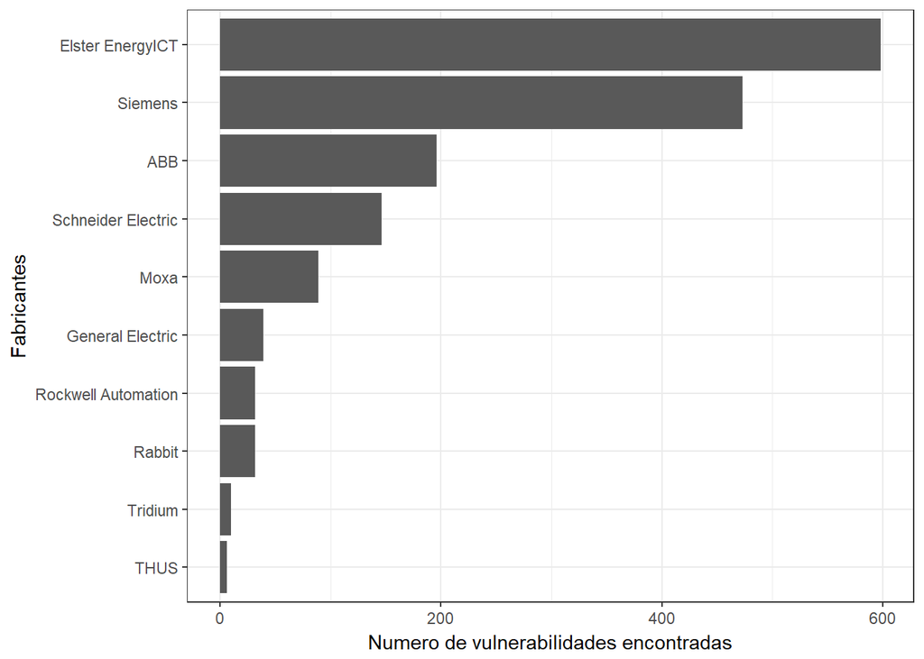

El siguiente paso es visualizar los países que más vulnerabilidades tienen en función de todos los dispositivos industriales encontrados. Se analiza en un mapa de calor los países con más vulnerabilidades.

Figura 5 - Vulnerabilidades por paises

[interactive chart not shown]

Figura 6 - Top 10 de países con más vulnerabilidades

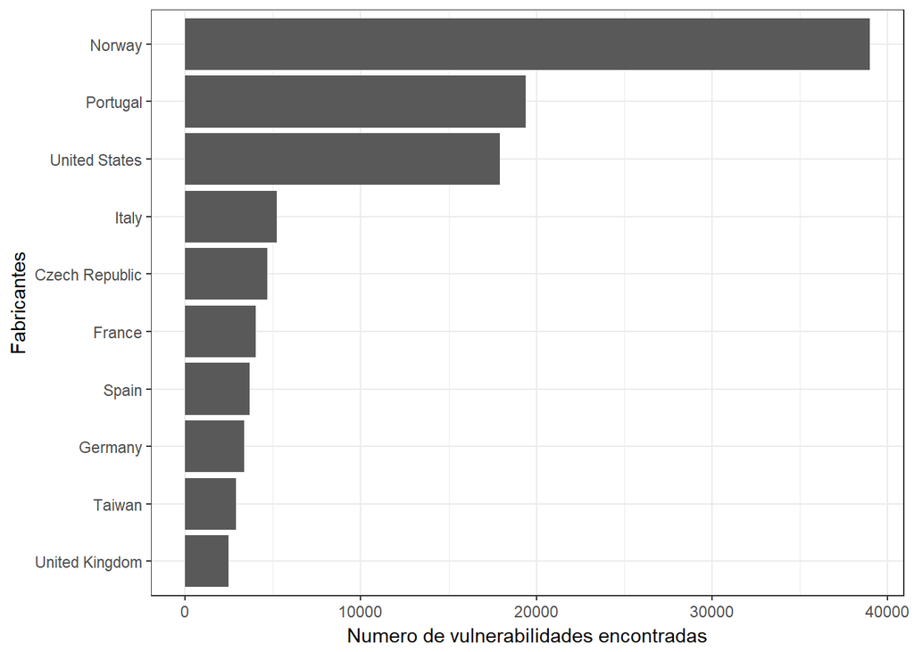

Comparando los resultados reflejados en la Figura 3 y en e Figura 5, se observa como existe una diferencia entre la primera y la segunda porque no se ven reflejadas la mayoría de las ubicaciones de las vulnerabilidades con el país que refleja que tiene más dispositivos vulnerables. Es decir, a pesar de que EEUU tiene más dispositivos industriales, es Noruega el que tiene más dispositivos vulnerables. Noruega tiene menos dispositivos industriales pero tiene muchos del fabricante Elster EneryICT. Tal como hemos dicho, este fabricante es el primero en vulnerabilidades publicadas en el CVE.

# 5. Conclusiones

# 6. Listado de tablas y figuras

- Tabla 1 - Listado de dispositivos industriales
- Tabla 2 - Listado de dispositivos industriales econtrados en Shodan
- Tabla 3 - Listado de vulnerabilidads CVE
- Figura 1 - Reparto de dispositivos industriales encontrados
- Figura 2 - Posicion GPS de los dispositivos industriales
- Figura 3 - Mapa de calor de los dispostivos industriales
- Figura 4 - Vulnerabilidades por fabricante
- Figura 5 - Vulnerabilidades por paises
- Figura 6 - Top 10 de paises con más vulnerabilidades

# 7. Referencias utilizadas

- [Hacer y documentar un paquete de R en 20 minutos](https://mauriciogtec.github.io/rGallery/entries/tutoriales/crear_paquetes/crear_paquete.html)
- [R Markdown Cheat Sheet](https://www.rstudio.com/wp-content/uploads/2015/02/rmarkdown-cheatsheet.pdf)
- [Shodan API](https://developer.shodan.io)
- [CVE Mitre](https://cve.mitre.org)
- [Leaflet Maps](https://rstudio.github.io/leaflet/)